# HW 5: Spatial Models

Patrick Sydow

2/20/2022

1. Examine if there is evidence of spatial dependence in a rare and a common species in the BCI tree dataset

```r
rm(list = ls(all = TRUE))

library(vegan)
data(BCI)
## UTM Coordinates (in metres)
BCI_xy = data.frame(x = rep(seq(625754, 626654, by=100), each=5),
                    y = rep(seq(1011569,  1011969, by=100), len=50))
```

Determine what is rare and what is common…

Common species are found in many plots.

Rare species are found in few plots but can be abundant in those plots.

Cycle through abundance data at sites to find “rare” and “common” species. (result not knitted due to large number of plots)

```r
##for (i in 1:ncol(BCI)) {
  ##hist(BCI[,i], data = BCI)
  ##mtext(names(BCI[i]))
##}
```

Faramea.occidentalis = common

Inga.pezizifera = rare

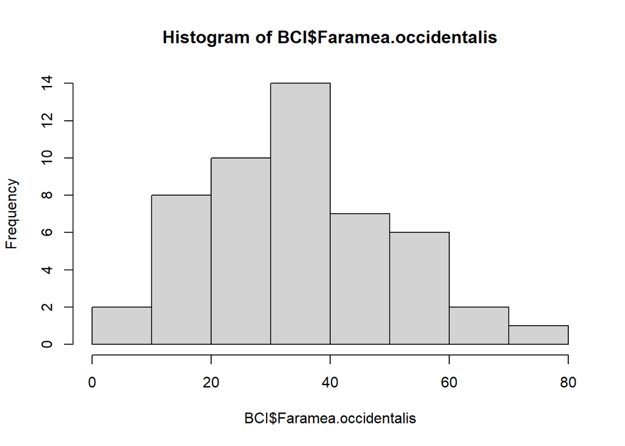

```r
hist(BCI$Faramea.occidentalis)
```

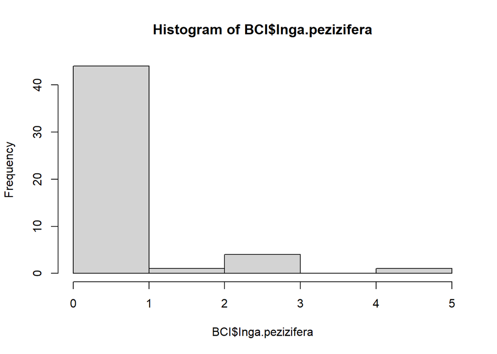

```r
hist(BCI$Inga.pezizifera)
```

Examine evidence in common species: Faramea occidentalis.

```r
library(dplyr)
```

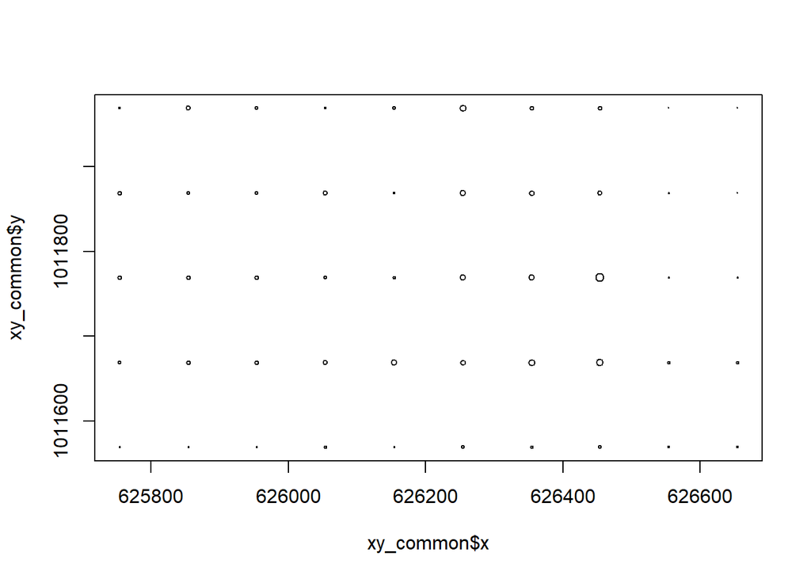

```r
abund_common <- BCI %>% select(Faramea.occidentalis)
colnames(abund_common) <- c('abund_common')
xy_common <-  abund_common %>% bind_cols(BCI_xy)
plot(x = xy_common$x, y = xy_common$y, cex = xy_common$abund_common/max(xy_common$abund_common))
```

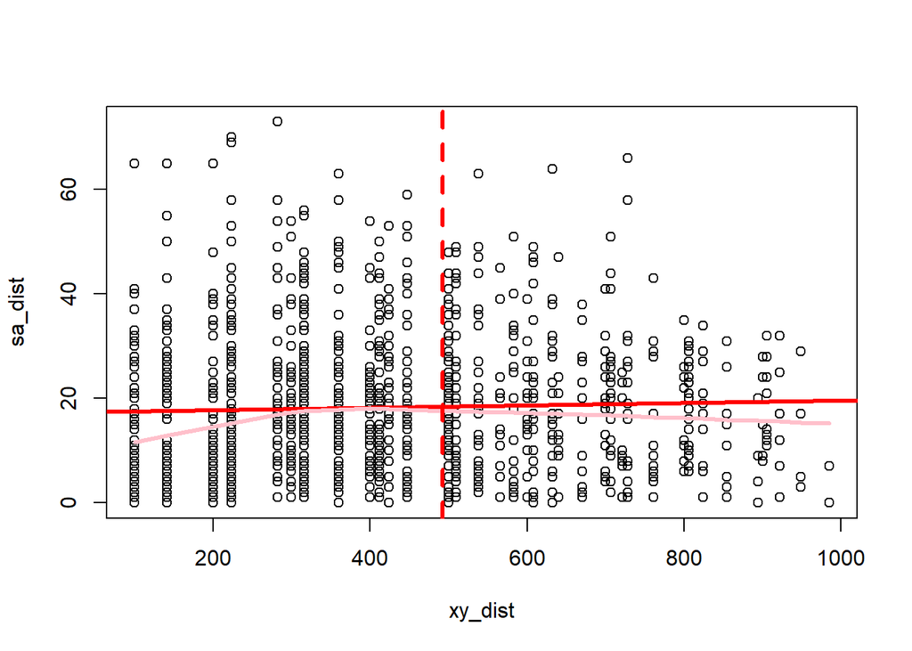

```r
# calculate Euclidean distance between abundance and spatial coordinates
sa_dist <- dist(abund_common)
xy_dist <- dist(BCI_xy)

# ensure that max distance of interpretation is no greater than 1/2 of max distance in data set
max_dist <- max(xy_dist) / 2

# plot result
plot(xy_dist, sa_dist)
abline(lm(sa_dist ~ xy_dist), lwd=3, col='red')
lines(lowess(xy_dist, sa_dist), lwd=3, col='pink')
abline(v = max_dist, col='red', lwd=3, lty=2)
```

According to this graph with a mostly flat horizontal correlation, species abundance for this common species does not seem to be spatially dependent.

```r
# calc. correlation
obs_cor <- cor(xy_dist, sa_dist)
obs_cor
```

```
## [1] 0.0355889
```

A small calculated correlation of 0.036 does not seem to support much of a correlation between xy_dist and sa_dist suggesting no spatial dependence for species abundance.

Let’s use the mantel() function to determine whether or not this observed correlation is greater than what we would expect due to random chance through a permutation test.

```r
# mantel permutation test function (p = # times (r null >= r obs) / # permutations)
common_mantel <- mantel(xy_dist, sa_dist)
common_mantel
```

```
##
## Mantel statistic based on Pearson's product-moment correlation
##
## Call:
## mantel(xdis = xy_dist, ydis = sa_dist)
##
## Mantel statistic r: 0.03559
##       Significance: 0.243
##
## Upper quantiles of permutations (null model):
##    90%    95%  97.5%    99%
## 0.0645 0.0843 0.1059 0.1338
## Permutation: free
## Number of permutations: 999
```

But, we can also use a correlogram to breakdown xy_dist into sections to see if the correlation between xy_dist and sa_dist may differ across the xy_dist axis.

```r
# correlogram to break down xy_dist into sections. Does correlation differ by section along xy_dist axis
common_corlog = mantel.correlog(sa_dist, xy_dist)
common_corlog
```

```
##
## Mantel Correlogram Analysis
##
## Call:
##
## mantel.correlog(D.eco = sa_dist, D.geo = xy_dist)
##
##         class.index     n.dist Mantel.cor Pr(Mantel) Pr(corrected)
## D.cl.1   136.870241 144.000000   0.041368      0.059         0.059 .
## D.cl.2   210.610723 376.000000   0.009563      0.360         0.360
## D.cl.3   284.351204 390.000000  -0.054005      0.023         0.069 .
## D.cl.4   358.091686 148.000000  -0.056782      0.011         0.044 *
## D.cl.5   431.832168 372.000000  -0.039064      0.114         0.228
## D.cl.6   505.572649 266.000000  -0.023481      0.138         0.342
## D.cl.7   579.313131 168.000000         NA         NA            NA
## D.cl.8   653.053613 100.000000         NA         NA            NA
## D.cl.9   726.794094 154.000000         NA         NA            NA
## D.cl.10  800.534576  88.000000         NA         NA            NA
## D.cl.11  874.275058  50.000000         NA         NA            NA
## D.cl.12  948.015539  24.000000         NA         NA            NA
## ---
## Signif. codes:  0 '***' 0.001 '**' 0.01 '*' 0.05 '.' 0.1 ' ' 1
```

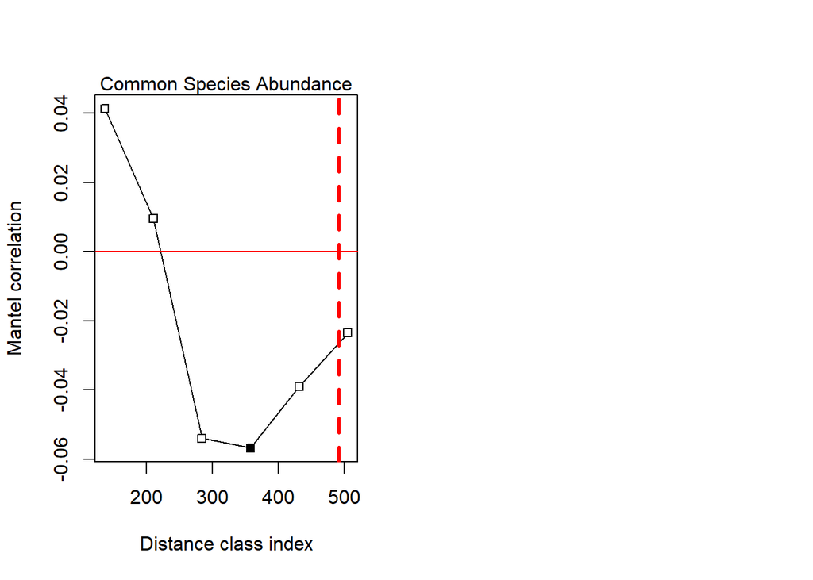

```r
# plot correlogram result
par(mfrow=c(1,2))
plot(common_corlog)
mtext(side=3, 'Common Species Abundance')
abline(v = max_dist, col='red', lwd=3, lty=2)
```

These results suggests that there is not spatial dependence for species abundance and that differences in species abundance across space are not larger than expected if they were due to chance.

Examine evidence in rare species: Inga pezizifera

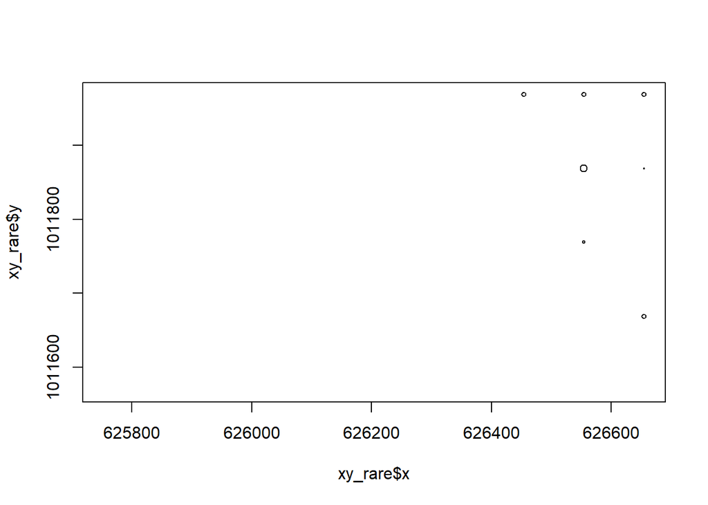

```r
abund_rare <- BCI %>% select(Inga.pezizifera)
colnames(abund_rare) <- c('abund_rare')
xy_rare <-  abund_rare %>% bind_cols(BCI_xy)
plot(x = xy_rare$x, y = xy_rare$y, cex = xy_rare$abund_rare/max(xy_rare$abund_rare))
```

According to this plot, the distribution of the rare species seems to be concentrated in the upper right plots of the experimental set up. Let’s test for spatial independence starting with calculating and ploting the euclidean distances between plot location and species abundance points.

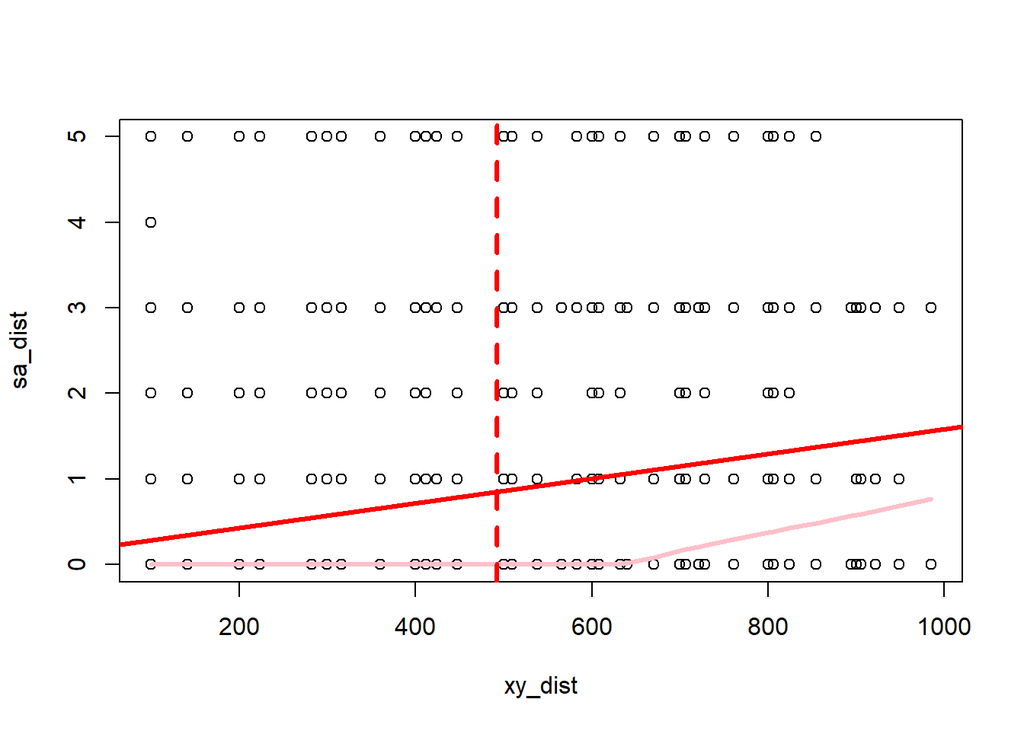

```r
# calculate Euclidean distance between abundance and spatial coordinates
sa_dist <- dist(abund_rare)
xy_dist <- dist(BCI_xy)

# do the plot thing
max_dist <- max(xy_dist) / 2

# plot result
plot(xy_dist, sa_dist)
abline(lm(sa_dist ~ xy_dist), lwd=3, col='red')
lines(lowess(xy_dist, sa_dist), lwd=3, col='pink')
abline(v = max_dist, col='red', lwd=3, lty=2)
```

There seems to be a slight positive correlation between xy_dist and sa_dist suggesting species abundance may have spatial dependence. Let’s calculate the actual correlation.

```r
# calc. correlation
obs_cor <- cor(xy_dist, sa_dist)
obs_cor
```

```
## [1] 0.2228425
```

The observed correlation for this rare species is certainly higher than that of the common species but let’s use mantel() to see if it is larger than it would be due to chance.

```r
# mantel permutation test function (p = # times (r null >= r obs) / # permutations)
rare_mantel <- mantel(xy_dist, sa_dist)
rare_mantel
```

```
##
## Mantel statistic based on Pearson's product-moment correlation
##
## Call:
## mantel(xdis = xy_dist, ydis = sa_dist)
##
## Mantel statistic r: 0.2228
##       Significance: 0.002
##
## Upper quantiles of permutations (null model):
##    90%    95%  97.5%    99%
## 0.0894 0.1140 0.1315 0.1575
## Permutation: free
## Number of permutations: 999
```

```r
#correlogram to break down xy_dist into sections. Does correlation differ by section along xy_dist axis
rare_corlog = mantel.correlog(sa_dist, xy_dist)
rare_corlog
```

```
##
## Mantel Correlogram Analysis
##
## Call:
##
## mantel.correlog(D.eco = sa_dist, D.geo = xy_dist)
##
##         class.index      n.dist  Mantel.cor Pr(Mantel) Pr(corrected)
## D.cl.1  136.8702408 144.0000000   0.0541970      0.004         0.004 **
## D.cl.2  210.6107225 376.0000000   0.0805706      0.001         0.002 **
## D.cl.3  284.3512042 390.0000000   0.0499076      0.024         0.024 *
## D.cl.4  358.0916859 148.0000000   0.0420179      0.004         0.012 *
## D.cl.5  431.8321676 372.0000000   0.0131258      0.349         0.349
## D.cl.6  505.5726492 266.0000000  -0.0069383      0.352         0.698
## D.cl.7  579.3131309 168.0000000          NA         NA            NA
## D.cl.8  653.0536126 100.0000000          NA         NA            NA
## D.cl.9  726.7940943 154.0000000          NA         NA            NA
## D.cl.10 800.5345760  88.0000000          NA         NA            NA
## D.cl.11 874.2750577  50.0000000          NA         NA            NA
## D.cl.12 948.0155393  24.0000000          NA         NA            NA
## ---
## Signif. codes:  0 '***' 0.001 '**' 0.01 '*' 0.05 '.' 0.1 ' ' 1
```

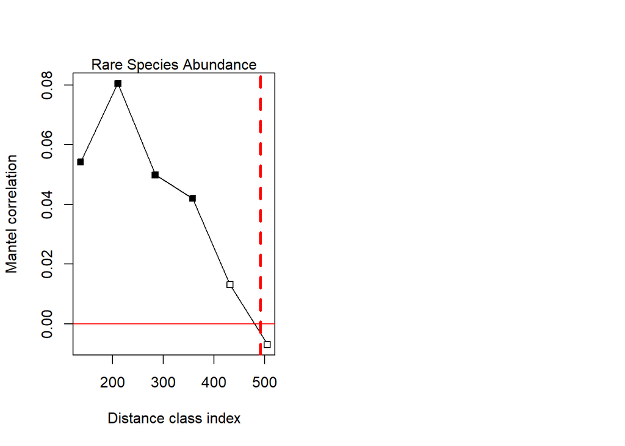

```r
#plot correlogram result
par(mfrow=c(1,2))
plot(rare_corlog)
mtext(side=3, 'Rare Species Abundance')
abline(v = max_dist, col='red', lwd=3, lty=2)
```

Unlike the common species, the correlation for the rare species is almost always positive and also significant for most tests along the xy_dist axis. These results suggests that there is spatial dependence for species abundance and that differences in species abundance across space are larger than expected if they were due to chance.

2. Build two generalized linear models to predict the abundance of the species Drypetes standleyi using the abundance of other tree species in the study site. Specifically examine the following species as predictor variables:

sp_ids = c(“Cordia.lasiocalyx”, “Hirtella.triandra”, “Picramnia.latifolia”, “Quassia.amara”, “Tabernaemontana.arborea”, “Trattinnickia.aspera”, “Xylopia.macrantha”)

Let’s prepare a single data frame to run these models.

```r
### select these species and place them in an "explanatory variables" df
BCI_exp <- BCI %>% select(Cordia.lasiocalyx, Hirtella.triandra,
           Picramnia.latifolia, Quassia.amara,
           Tabernaemontana.arborea, Trattinnickia.aspera,
           Xylopia.macrantha)
### rename columns for species to have simpler names
colnames(BCI_exp) <- c('a', 'b', 'c', 'd', 'e', 'f', 'g')
### create "response variable" df with just Drypetes standleyi and rename column "sp_abund"
BCI_resp <- BCI %>% select(Drypetes.standleyi)
colnames(BCI_resp) <- c('sp_abund')
### put dataframes together for model construction
sa_dat = data.frame(BCI_resp, BCI_exp, BCI_xy)
```

Let’s begin constructing these models beginning with a model containing all species as explanatory variables and also a model with all species containing a nugget.

```r
library(nlme)
```

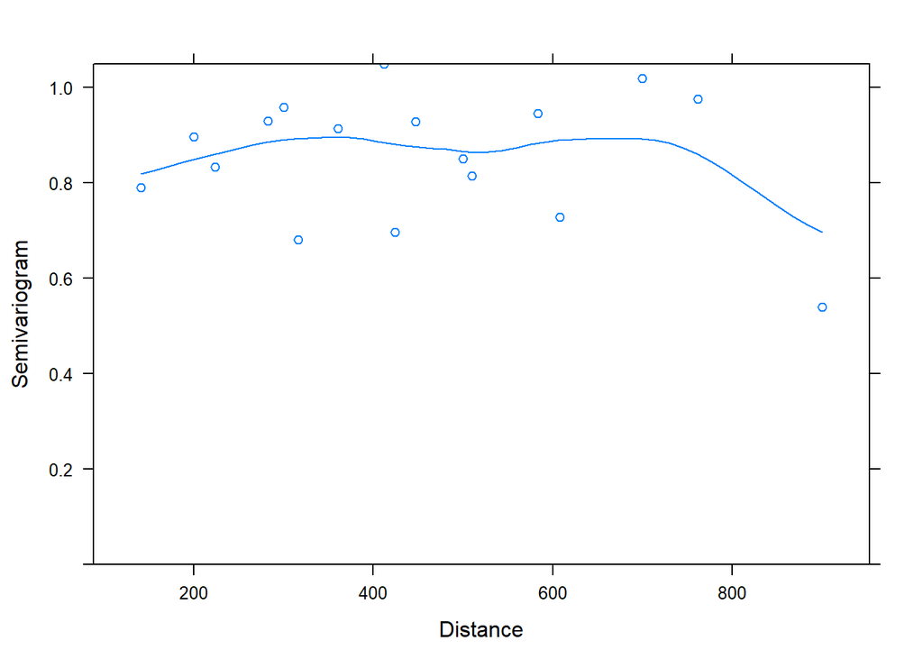

```r
#create model containing all species as explanatory variables
sa_exp = gls(sp_abund ~ a + b + c + d + e + f + g, data=sa_dat)
#plot error to check independence of error
plot(Variogram(sa_exp, form= ~ x + y))
```

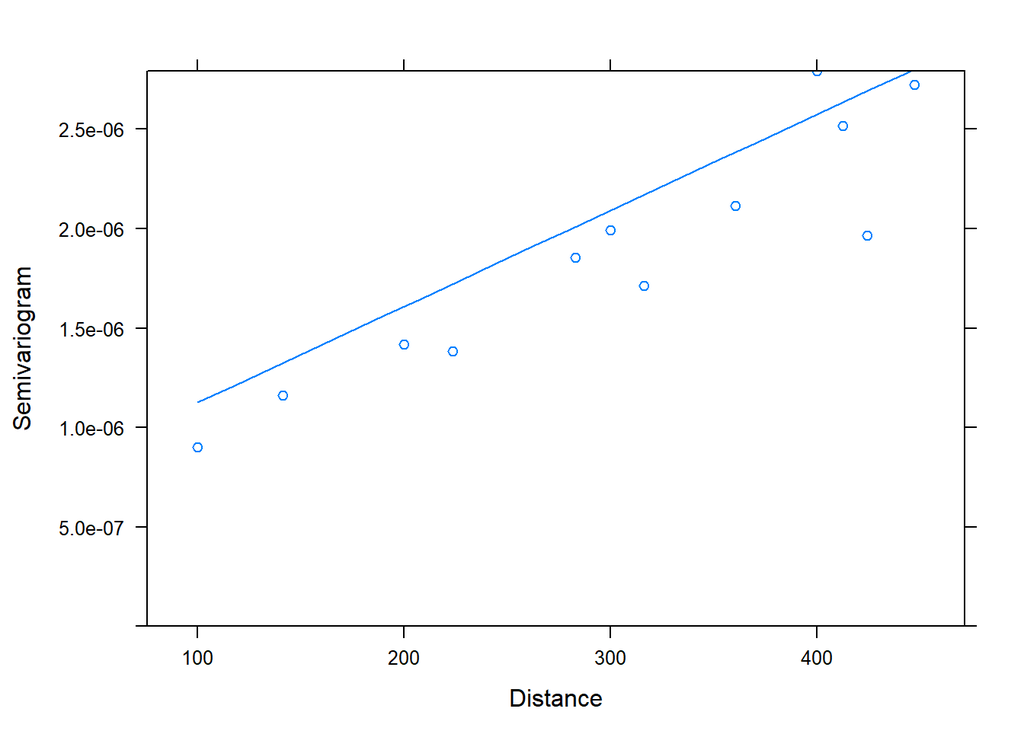

```r
#add a nugget to model
sa_exp_nug = update(sa_exp, corr=corExp(form=~x + y, nugget=T))
#plot error of model with nugget added with unnormalized and normalized residuals
plot(Variogram(sa_exp_nug, maxDist = max_dist))
```

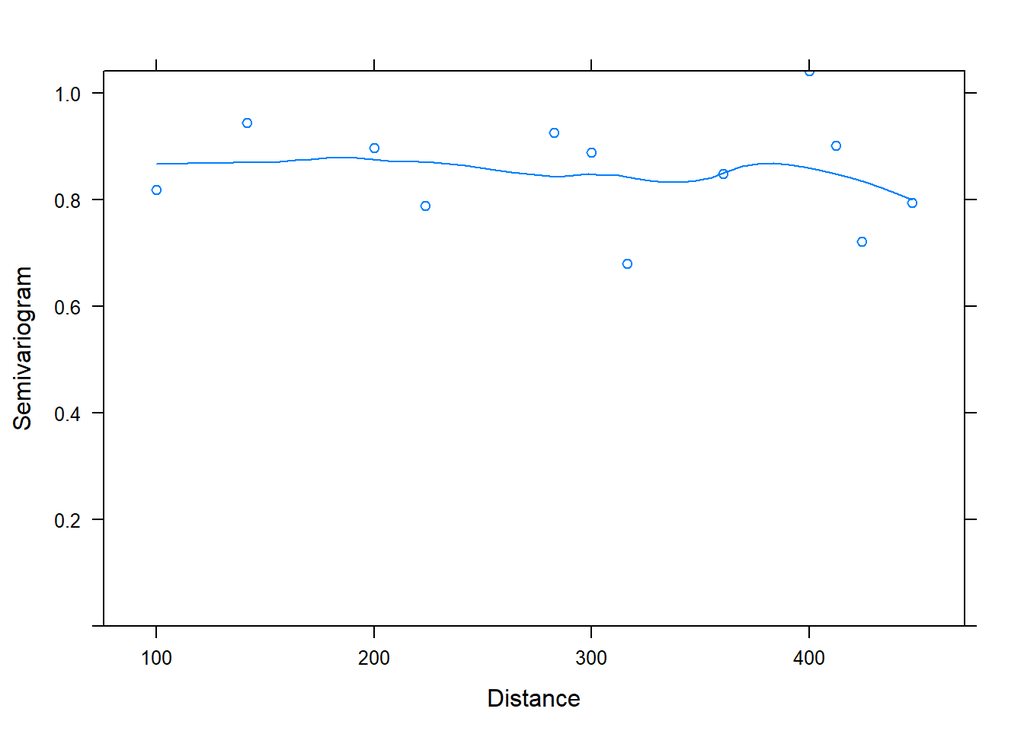

```r
plot(Variogram(sa_exp_nug, maxDist = max_dist, resType = 'normalized'))
```

According to the semivariograms, the model containing a nugget seems to fit the error better than the model without the nugget. There also does not seem to be a trend in the normalized residuals which is good.

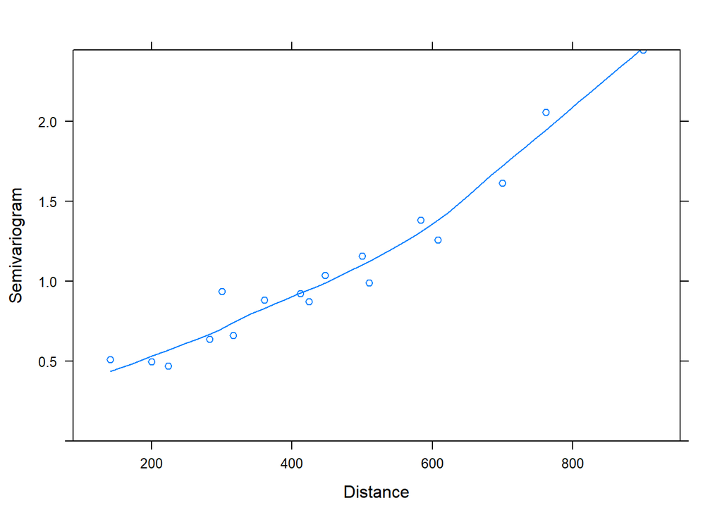

```r
# g seems like an important variable, make model with just one variable
sa_g = gls(sp_abund ~ g, data=sa_dat)
plot(Variogram(sa_g, form= ~ x + y))
```

```r
#add a nugget

## sa_g_nug = update(sa_g, corr=corExp(form=~x + y, nugget=T))

## false convergence error (8), essentially because effect of adding a nugget is so small

#compare all three models: all inclusive, all inclusive + nugget, and just g

anova(sa_exp, sa_exp_nug, sa_g, test=F)
```

```
##            Model df      AIC      BIC    logLik
## sa_exp         1  9 307.1163 322.7554 -144.5582
## sa_exp_nug     2 11 301.9592 321.0735 -139.9796
## sa_g           3  3 338.2919 343.9055 -166.1459
```

According to the AIC scores, the best model in the sa_exp_nug model with all species included with a nugget. But, this seems odd because of how good the sa_g model semivariogram appears as well as how complex the all inclusive models are. We would think that the more complex model that does not model error well would have a higher AIC score. But, let’s look at the summaries of these models.

```r
summary(sa_exp)
```

```
## Generalized least squares fit by REML
##   Model: sp_abund ~ a + b + c + d + e + f + g
##   Data: sa_dat
##        AIC      BIC    logLik
##   307.1163 322.7554 -144.5582
##
## Coefficients:
##                 Value Std.Error   t-value p-value
## (Intercept) -1.051752 2.1175346 -0.496687  0.6220
## a            0.428920 0.2039316  2.103255  0.0415
## b            0.122279 0.0802638  1.523462  0.1351
## c            0.662259 0.6358905  1.041468  0.3036
## d            4.085661 2.2842770  1.788602  0.0809
## e           -0.249725 0.1491192 -1.674667  0.1014
## f            1.349323 0.7147412  1.887848  0.0660
## g            0.548832 0.1468772  3.736672  0.0006
##
##  Correlation:
##   (Intr) a      b      c      d      e      f
## a -0.618
## b -0.212 -0.354
## c  0.025 -0.019 -0.381
## d  0.163 -0.378  0.307 -0.302
## e -0.708  0.245  0.163 -0.113  0.148
## f -0.139  0.187 -0.311  0.308 -0.708 -0.144
## g -0.140 -0.125  0.156 -0.463  0.314  0.279 -0.294
##
## Standardized residuals:
##         Min          Q1         Med          Q3         Max
## -1.87708765 -0.42701500 -0.04032793  0.23615609  3.38768871
##
## Residual standard error: 4.539713
## Degrees of freedom: 50 total; 42 residual
```

```r
summary(sa_exp_nug)
```

```
## Generalized least squares fit by REML
##   Model: sp_abund ~ a + b + c + d + e + f + g
##   Data: sa_dat
##        AIC      BIC    logLik
##   301.9592 321.0735 -139.9796
##
## Correlation Structure: Exponential spatial correlation
##  Formula: ~x + y
##  Parameter estimate(s):
##        range       nugget
## 2.069876e+08 6.423682e-07
##
## Coefficients:
##                  Value Std.Error   t-value p-value
## (Intercept)  3.0501207  3486.910  0.000875  0.9993
## a            0.1426665     0.190  0.752751  0.4558
## b           -0.0017716     0.090 -0.019602  0.9845
## c            0.2863333     0.527  0.542880  0.5901
## d            1.3263608     1.937  0.684817  0.4972
## e            0.0407531     0.140  0.292086  0.7717
## f            1.8170752     0.573  3.171304  0.0028
## g            0.4086698     0.154  2.659323  0.0110
##
##  Correlation:
##   (Intr) a      b      c      d      e      f
## a  0.000
## b -0.001 -0.098
## c  0.000  0.017 -0.360
## d  0.000 -0.292  0.344 -0.193
## e  0.000 -0.020  0.160 -0.197  0.088
## f  0.000  0.165 -0.276  0.255 -0.655 -0.036
## g  0.000 -0.066 -0.037 -0.048  0.306  0.140 -0.183
##
## Standardized residuals:
##           Min            Q1           Med            Q3           Max
## -0.0025251382 -0.0014891171 -0.0010582565  0.0002851465  0.0053085949
##
## Residual standard error: 3486.914
## Degrees of freedom: 50 total; 42 residual
```

```r
summary(sa_g)
```

```
## Generalized least squares fit by REML
##   Model: sp_abund ~ g
##   Data: sa_dat
##        AIC      BIC    logLik
##   338.2919 343.9055 -166.1459
##
## Coefficients:
##                Value Std.Error  t-value p-value
## (Intercept) 3.285252 1.0990108 2.989281  0.0044
## g           0.844318 0.1804326 4.679407  0.0000
##
##  Correlation:
##   (Intr)
## g -0.47
##
## Standardized residuals:
##        Min         Q1        Med         Q3        Max
## -1.3044324 -0.4788137 -0.3103771  0.1041720  3.9616489
##
## Residual standard error: 6.861233
## Degrees of freedom: 50 total; 48 residual
```

This does not seem to be revealing much about why the sa_exp_nug model has the lowest AIC score. But, it may be because the R^2 values of the complex sa_exp_nug and sa_exp model are much higher higher than the that of the sa_g model. This would justify their complexity.

Let’s see if adding a spatial error term impacts these models

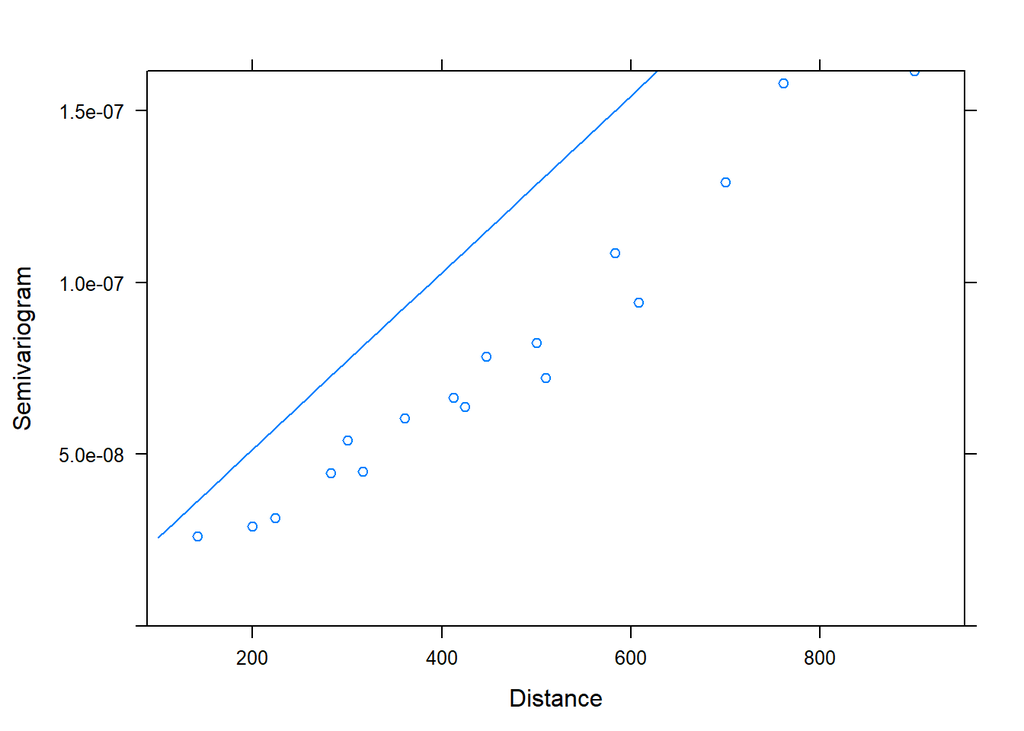

```r
#use corExp error term to display exponential residual model
sa_exp_g = update(sa_g, corr=corExp(form=~x + y))
plot(Variogram(sa_exp_g, form= ~ x + y))
```

```r
summary(sa_g)
```

```
## Generalized least squares fit by REML
##   Model: sp_abund ~ g
##   Data: sa_dat
##        AIC      BIC    logLik
##   338.2919 343.9055 -166.1459
##
## Coefficients:
##                Value Std.Error  t-value p-value
## (Intercept) 3.285252 1.0990108 2.989281  0.0044
## g           0.844318 0.1804326 4.679407  0.0000
##
##  Correlation:
##   (Intr)
## g -0.47
##
## Standardized residuals:
##        Min         Q1        Med         Q3        Max
## -1.3044324 -0.4788137 -0.3103771  0.1041720  3.9616489
##
## Residual standard error: 6.861233
## Degrees of freedom: 50 total; 48 residual
```

```r
summary(sa_exp_g)
```

```
## Generalized least squares fit by REML
##   Model: sp_abund ~ g
##   Data: sa_dat
##        AIC      BIC    logLik
##   308.6325 316.1173 -150.3163
##
## Correlation Structure: Exponential spatial correlation
##  Formula: ~x + y
##  Parameter estimate(s):
##      range
## 3889167290
##
## Coefficients:
##                 Value Std.Error   t-value p-value
## (Intercept) 13.820272 28257.965 0.0004891  0.9996
## g            0.292271     0.171 1.7064090  0.0944
##
##  Correlation:
##   (Intr)
## g 0
##
## Standardized residuals:
##           Min            Q1           Med            Q3           Max
## -0.0005304471 -0.0004890753 -0.0004182988 -0.0002590516  0.0006842074
##
## Residual standard error: 28257.97
## Degrees of freedom: 50 total; 48 residual
```

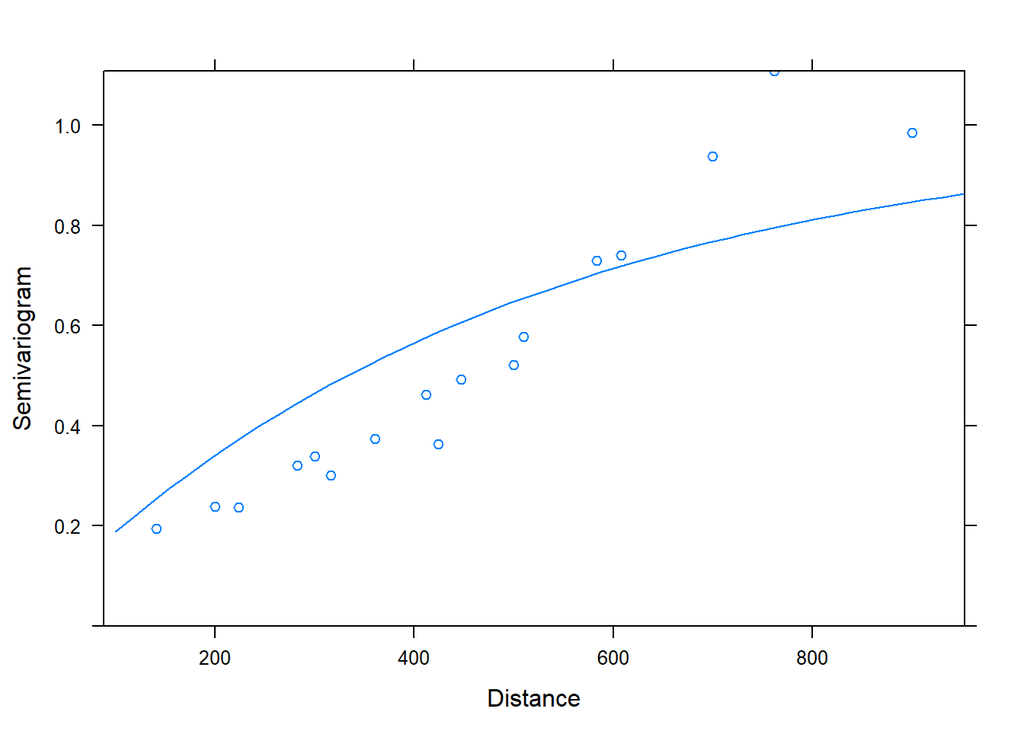

```r
#use corExp error term to display exponential residual model
sa_exp_exp_nug = update(sa_exp_nug, corr=corExp(form=~x + y))
plot(Variogram(sa_exp_exp_nug, form= ~ x + y))
```

```r
summary(sa_exp_nug)
```

```
## Generalized least squares fit by REML
##   Model: sp_abund ~ a + b + c + d + e + f + g
##   Data: sa_dat
##        AIC      BIC    logLik
##   301.9592 321.0735 -139.9796
##
## Correlation Structure: Exponential spatial correlation
##  Formula: ~x + y
##  Parameter estimate(s):
##        range       nugget
## 2.069876e+08 6.423682e-07
##
## Coefficients:
##                  Value Std.Error   t-value p-value
## (Intercept)  3.0501207  3486.910  0.000875  0.9993
## a            0.1426665     0.190  0.752751  0.4558
## b           -0.0017716     0.090 -0.019602  0.9845
## c            0.2863333     0.527  0.542880  0.5901
## d            1.3263608     1.937  0.684817  0.4972
## e            0.0407531     0.140  0.292086  0.7717
## f            1.8170752     0.573  3.171304  0.0028
## g            0.4086698     0.154  2.659323  0.0110
##
##  Correlation:
##   (Intr) a      b      c      d      e      f
## a  0.000
## b -0.001 -0.098
## c  0.000  0.017 -0.360
## d  0.000 -0.292  0.344 -0.193
## e  0.000 -0.020  0.160 -0.197  0.088
## f  0.000  0.165 -0.276  0.255 -0.655 -0.036
## g  0.000 -0.066 -0.037 -0.048  0.306  0.140 -0.183
##
## Standardized residuals:
##           Min            Q1           Med            Q3           Max
## -0.0025251382 -0.0014891171 -0.0010582565  0.0002851465  0.0053085949
##
## Residual standard error: 3486.914
## Degrees of freedom: 50 total; 42 residual
```

```r
summary(sa_exp_exp_nug)
```

```
## Generalized least squares fit by REML
##   Model: sp_abund ~ a + b + c + d + e + f + g
##   Data: sa_dat
##        AIC      BIC    logLik
##   301.6062 318.9829 -140.8031
##
## Correlation Structure: Exponential spatial correlation
##  Formula: ~x + y
##  Parameter estimate(s):
##    range
## 480.0567
##
## Coefficients:
##                 Value Std.Error  t-value p-value
## (Intercept) 2.3485197  6.154919 0.381568  0.7047
## a           0.1208390  0.179811 0.672033  0.5052
## b           0.0191759  0.098501 0.194677  0.8466
## c           0.2014516  0.509196 0.395627  0.6944
## d           1.2792289  1.847570 0.692385  0.4925
## e           0.0674943  0.133782 0.504511  0.6165
## f           1.8115374  0.525147 3.449582  0.0013
## g           0.3388574  0.156874 2.160064  0.0365
##
##  Correlation:
##   (Intr) a      b      c      d      e      f
## a -0.226
## b -0.309 -0.022
## c  0.045 -0.066 -0.369
## d -0.059 -0.304  0.321 -0.142
## e -0.240 -0.016  0.288 -0.221  0.112
## f -0.069  0.168 -0.237  0.212 -0.633 -0.041
## g -0.056 -0.137 -0.063  0.109  0.290  0.102 -0.186
##
## Standardized residuals:
##        Min         Q1        Med         Q3        Max
## -1.0051632 -0.5235683 -0.3176178  0.2208753  2.3746027
##
## Residual standard error: 8.628464
## Degrees of freedom: 50 total; 42 residual
```

Including the exponential spatial error term seems to have changed the coefficients of the model but more so in the sa_g model than the sa_exp model. But, the semivariograms are showing that the new models with these exponential error terms do not fit the error well at all.

Let’s compare how these terms effected the overall fit of the model using anova()

```r
anova(sa_g, sa_exp_g)
```

```
##          Model df      AIC      BIC    logLik   Test  L.Ratio p-value
## sa_g         1  3 338.2919 343.9055 -166.1459
## sa_exp_g     2  4 308.6325 316.1173 -150.3163 1 vs 2 31.65933  <.0001
```

```r
anova(sa_exp_nug, sa_exp_exp_nug)
```

```
##                Model df      AIC      BIC    logLik   Test  L.Ratio p-value
## sa_exp_nug         1 11 301.9592 321.0735 -139.9796
## sa_exp_exp_nug     2 10 301.6062 318.9829 -140.8031 1 vs 2 1.646998  0.1994
```

It looks like adding the exponential error term to the simple sa_g model improved the fit significantly. But, although it decreased the AIC score of the model, adding the term to the more complex model did not have a significant effect on model fit.

Changing the error in the simple sa_g model had a larger effect because of how differently the model modeled the residuals (big difference in semivariogram plot). Changing the error term in the more complex model did not have as drastic of an effect on how the model modeled the residuals (less difference in semivariogram plot)

Let’s look and see how the residuals of the sa_exp_nug are spatially structured

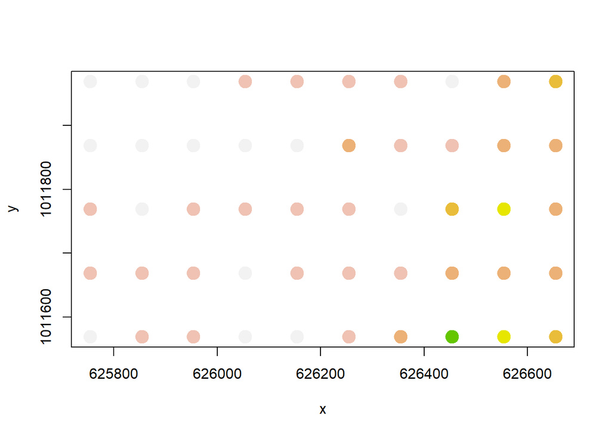

```r
col_brks = hist(residuals(sa_exp_nug), plot=F)$breaks
col_indices = as.numeric(cut(residuals(sa_exp_nug), col_brks))
cols = rev(terrain.colors(length(col_brks)))
plot(BCI_xy, cex=2, pch=19, col=cols[col_indices])
```